# P4_project

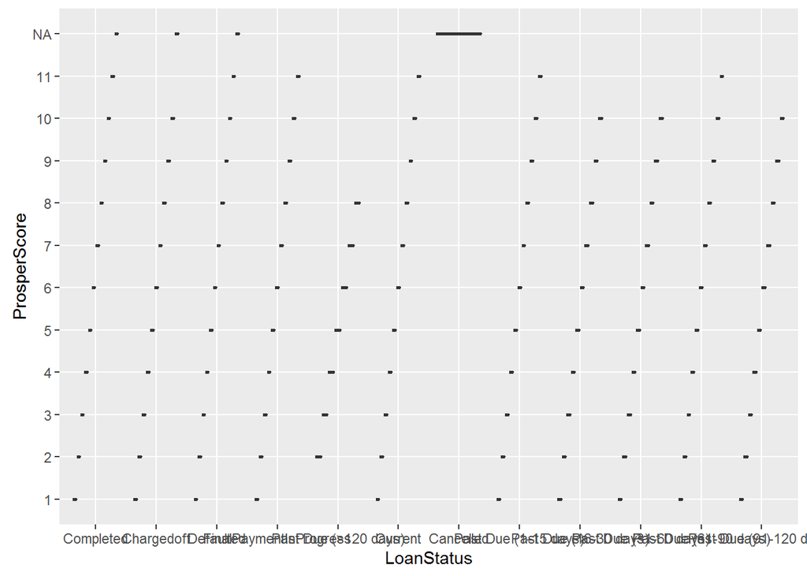

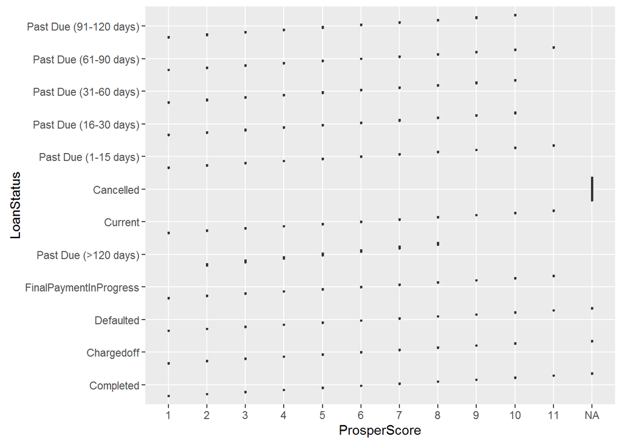

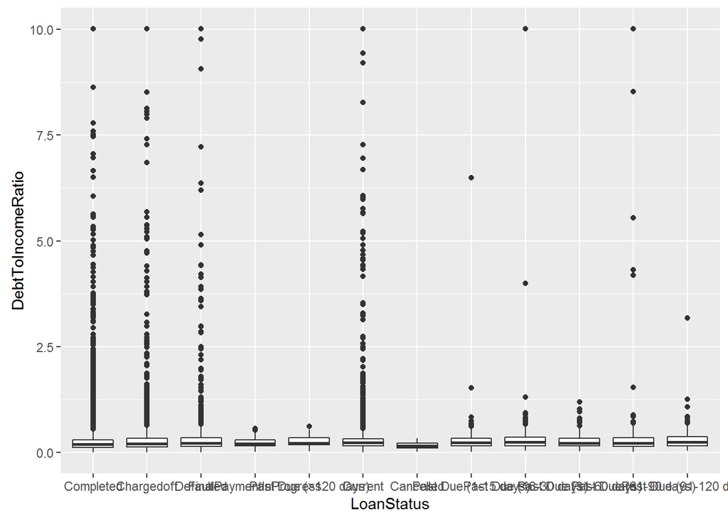

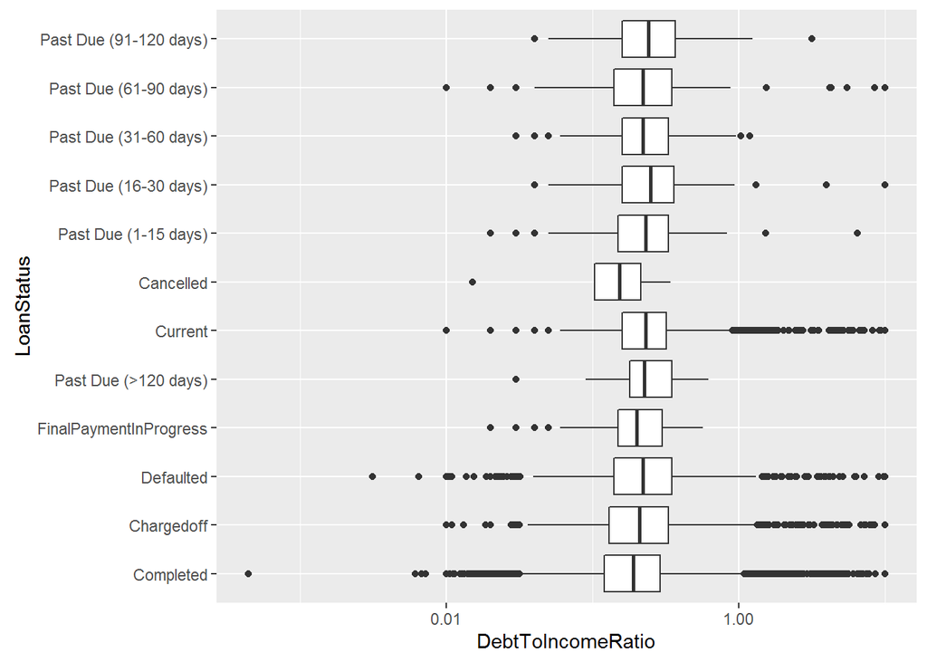

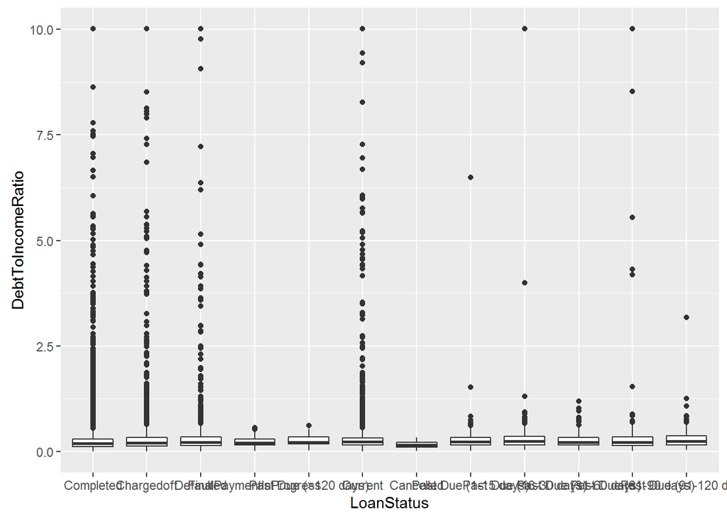

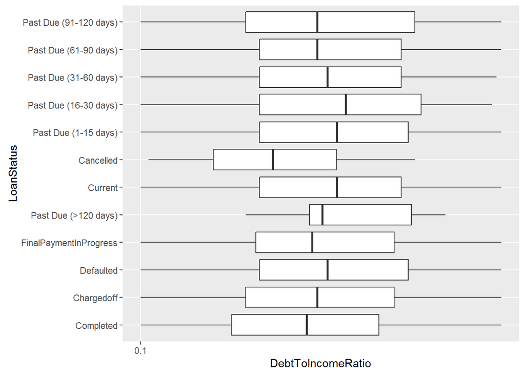

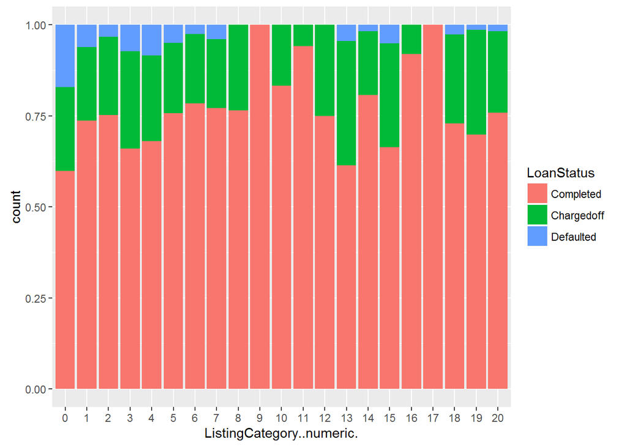

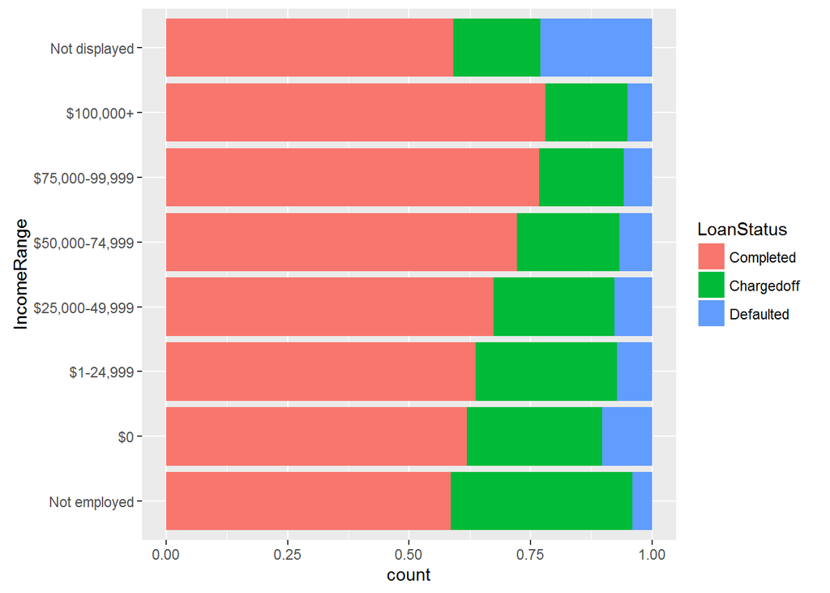

# Multivariate Plots Section

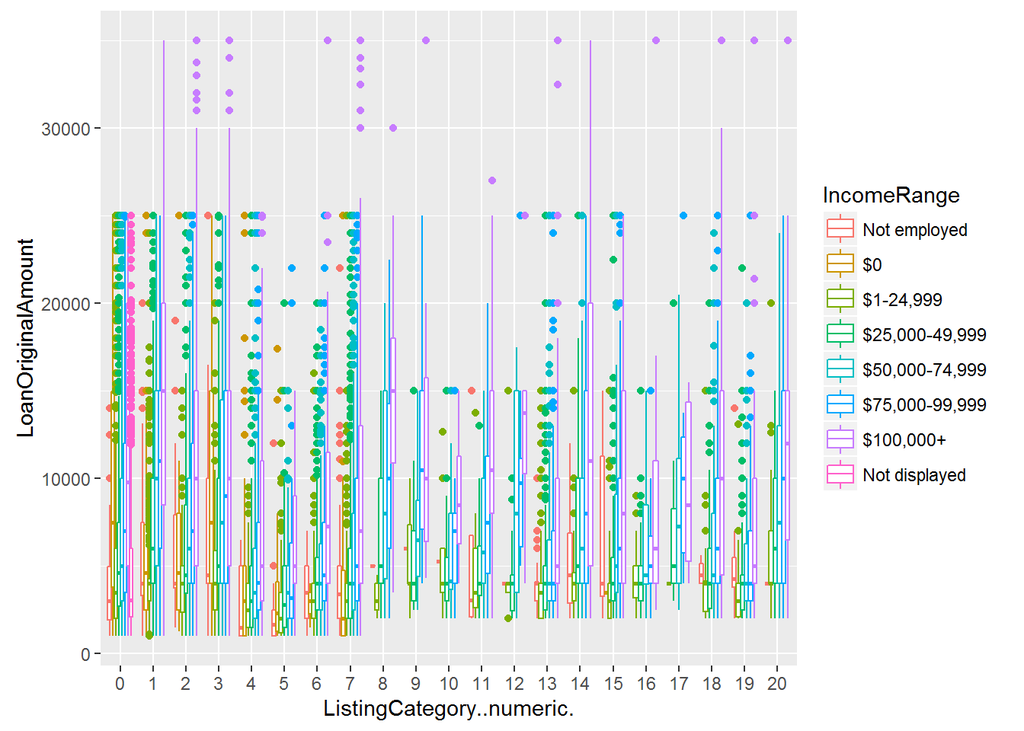

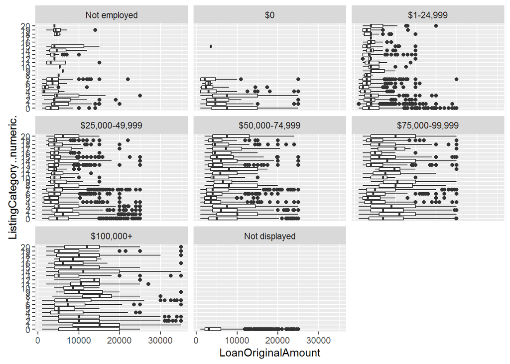

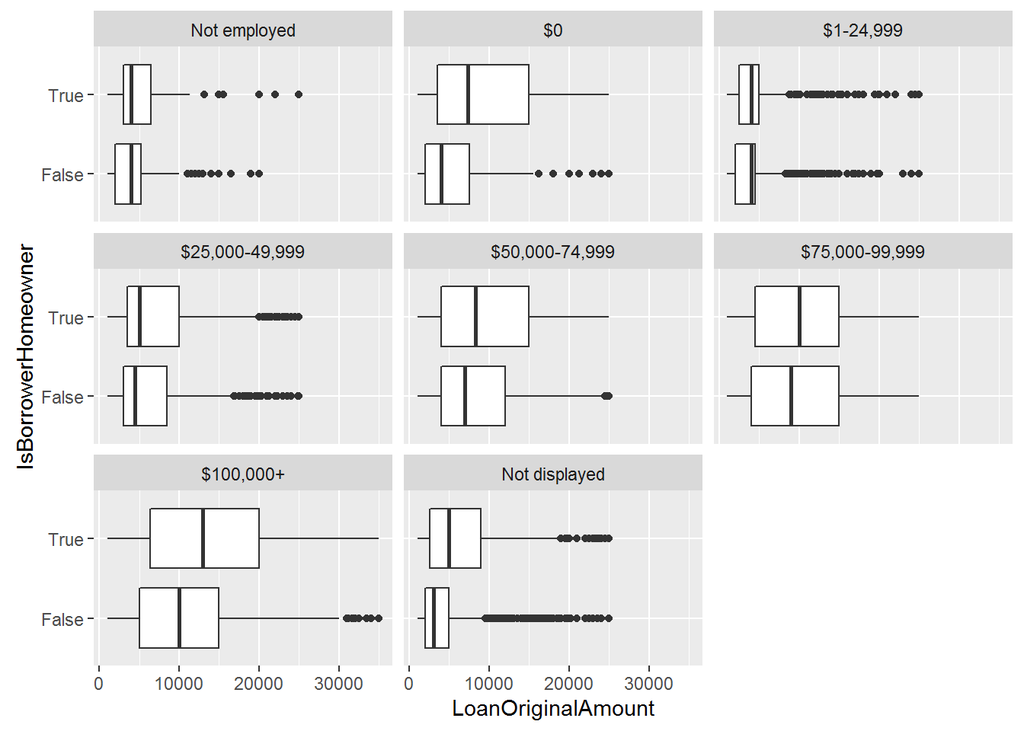

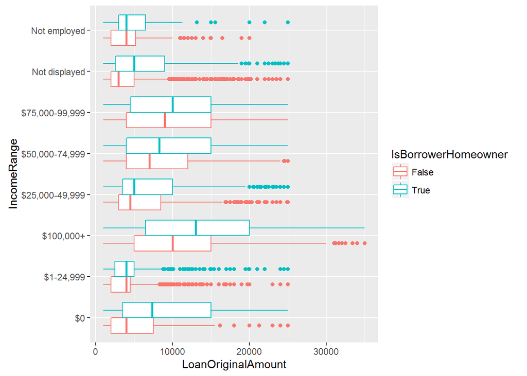

### Plot One

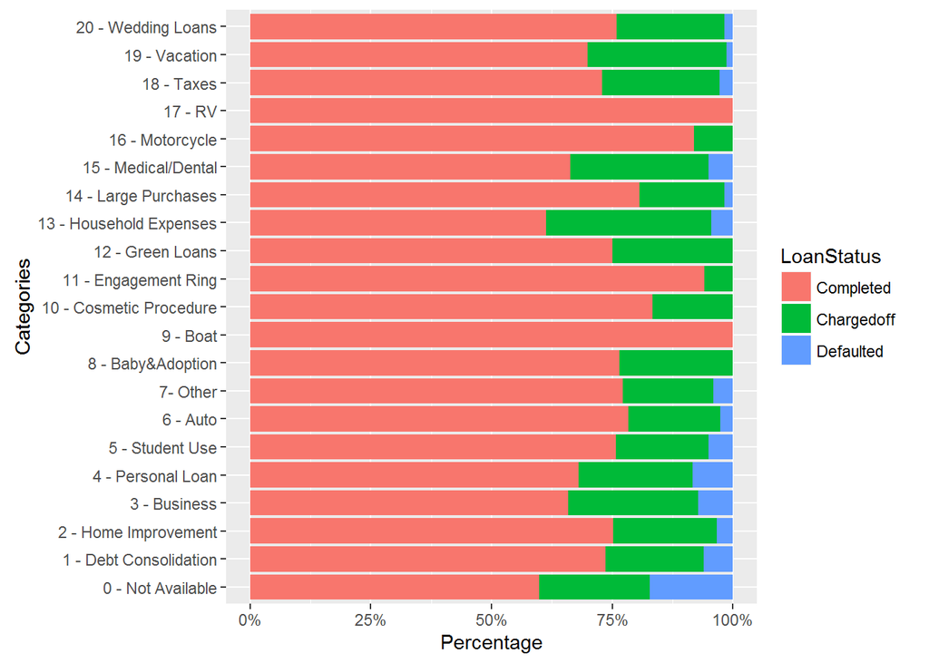

### Description One

This graph show the relative percentage of the three loan status(Completed,Chargedoff,Defaulted) for each categories, I find RV,Motorcycle,Engagement Ring,Boad are the categories have the largest relative percentage of completed loan. It means these kind of loan are less risky than others ### Plot Two

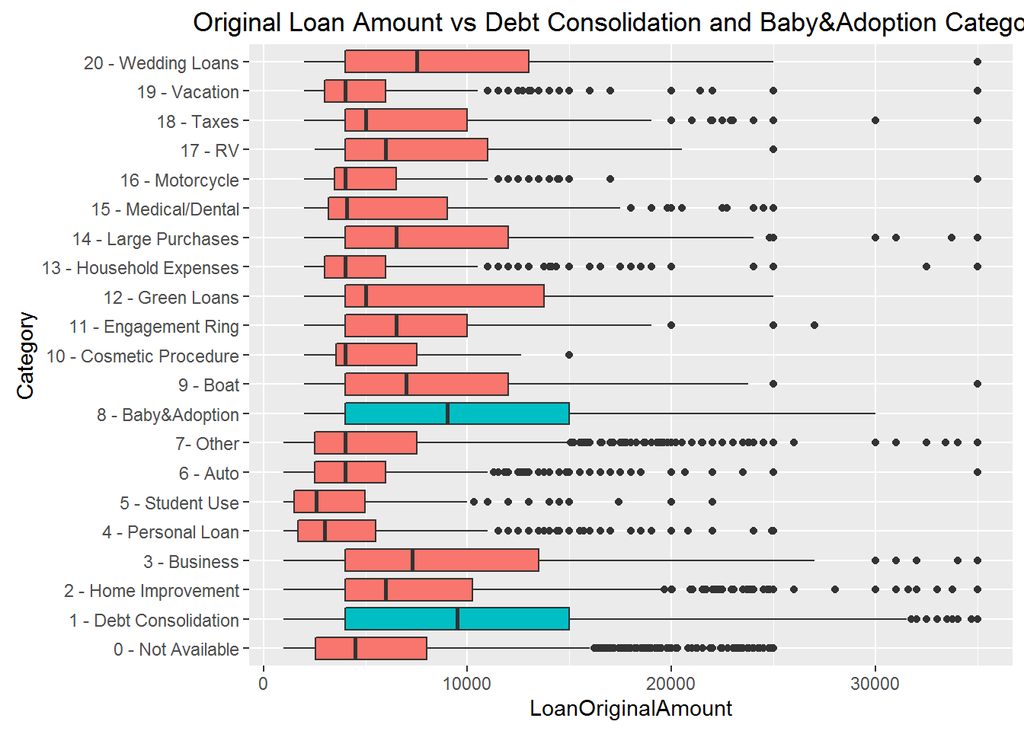

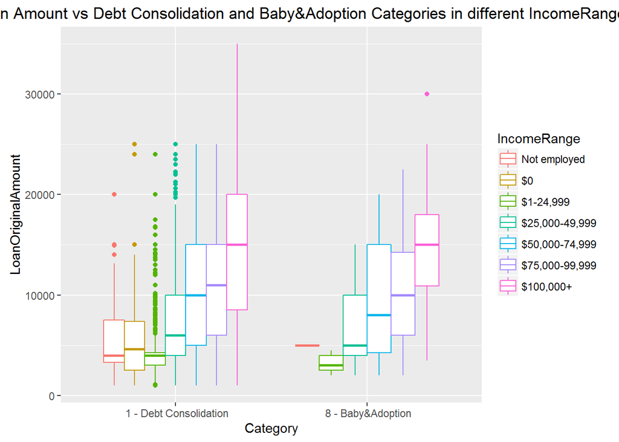

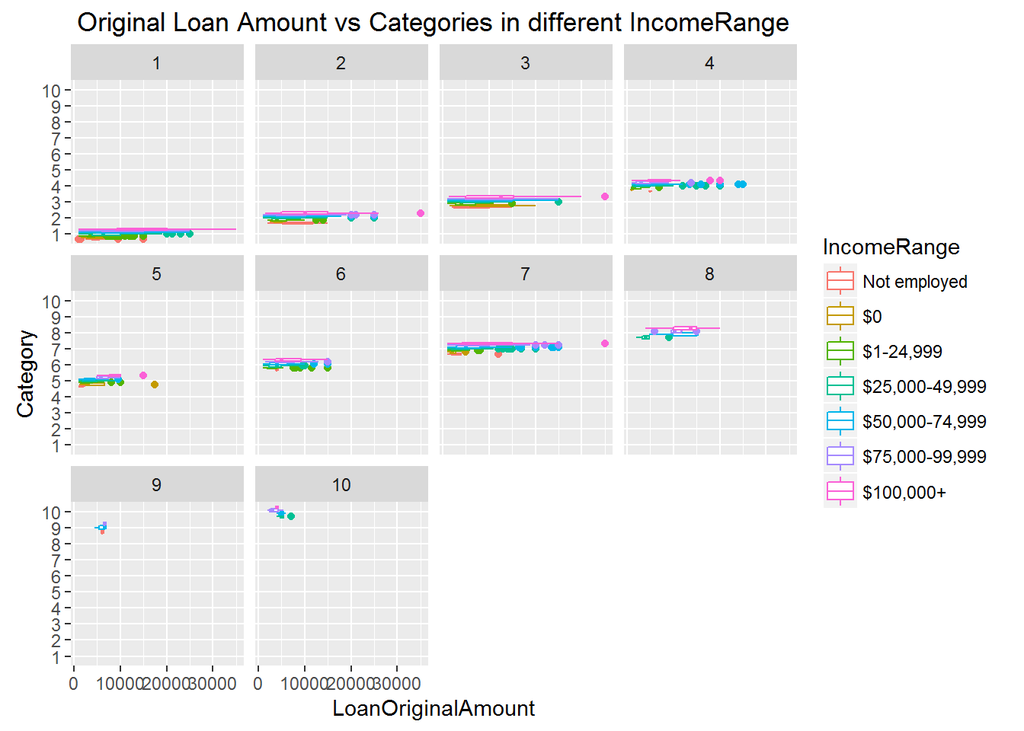

## The first graph shows Loan Amount median grow with IncomeRange in these 2 categories, which have the largest median loan amount among all categories. This general trend stay true even in other categories as in the second graph.

### Plot Three

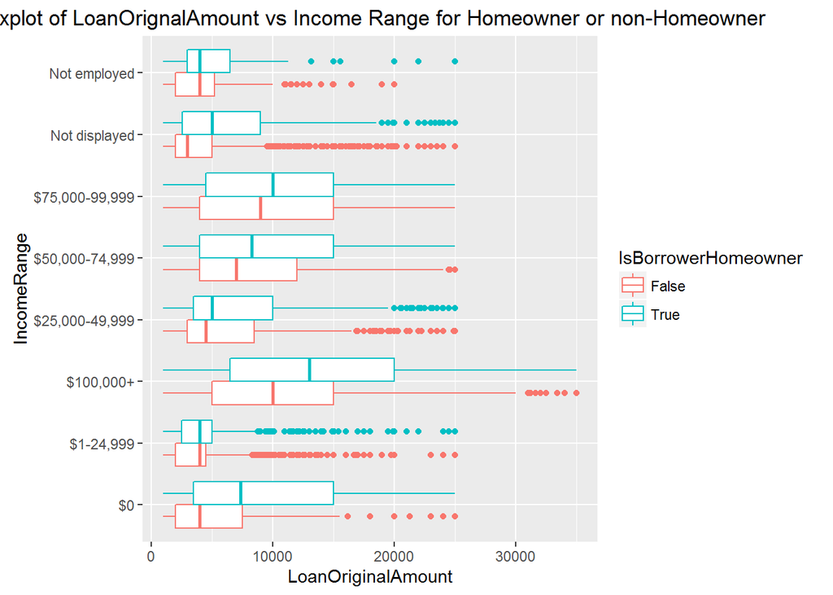

## Boxplot of LoanOrignalAmount vs Income Range for Homeowner or non-Homeowner,Homeowner have higher loan amount in almost each income range group.

# Reflection

The Prosper Loan data set contain more than 100000 observations for 81 variables which is too much to explore for one project.Therefore, I have pick about 10 variables to explore what factors affect Loan amount. I plan to do a linear regression but I find too much variable and I do not know how should I do regression on categorical data.

Homeowner,income range appears to affect the loan amount significantly. I also try to find which categories have the largest portion of completed loan, which I find people loan for Boat ,Recreational vehicles(RV), Motorcycle , Engagement Ring have the highest completed percentage, which are luxury items.

I find extremely hard to decide which variable to choose, I hope there are some guide question and suggested variable, but it is also the real world situation(probably much more data). There are some discontinuity in the data, for example, the grading system change from credit grade to ProsperScore. Since there are so many data, I want to do a machine learning algorithm to selected variable for me, I imagine it is impossible to explore every variable in real life if we get 100,1000 variables. Some of the variables is highly correlated, so the selection process must be very careful, it is time consuming to understand what are the data by reading the metadata and googling.

This is a fairly large data set,sometimes it force my Rstudio to shut down. There are lots to investigate for this dataset. Relations between return and background of customer. Which kind of loan is the most profitable one? We may even do a cluster analysis to see how naturally these loan are seperated.